# SI Course Project II

DM Rochman

August 22, 2015

==========================

### OVERVIEW

This report is an analysis of a data set based on a study of the effects of vitamin C on tooth growth in guinea pigs (C. I. Bliss (1952) The Statistics of Bio assay. Academic Press). The data set contains three variables and 60 observations of sixty guinea pigs. The outcome variable is the length of each subjects teeth. The two independent variables are dose and delivery method. Three dose levels of Vitamin C (0.5, 1, and 2 mg) were administered by either orange juice or ascorbic acid.

### METHODS

To begin, I separated the observations to vitamin C (VC) and orange juice (OJ) and then observed their basic descriptive statistics. I ran a box plot of the two delivery methods on the outcome, the data shows there is more significant growth with the orange juice delivery method.

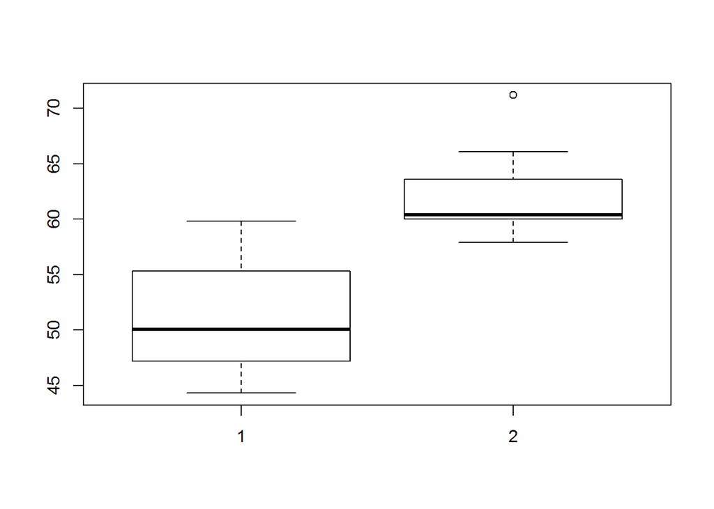

```r
library(datasets); data("ToothGrowth")

g1 <- ToothGrowth$len [1:10]; g2 <- ToothGrowth$len [31:40]; g3 <- ToothGrowth$len [11:20];
        g4 <- ToothGrowth$len [41:50]; g5 <- ToothGrowth$len [21:30]; g6 <- ToothGrowth$len[51:60]
VC <- g1 + g3 + g5
OJ <- g2 + g4 + g6
boxplot(VC,OJ)
```

I then performed three separate t-tests on the grouped observations based on delivery method and dosage level.

```r
t.test(g2,g1, paired = FALSE); t.test(g3, g4, paired = FALSE); t.test(g5,g6, paired = FALSE)
```

```
##
##  Welch Two Sample t-test
##
## data:  g2 and g1
## t = 3.1697, df = 14.969, p-value = 0.006359
## alternative hypothesis: true difference in means is not equal to 0
## 95 percent confidence interval:
##  1.719057 8.780943
## sample estimates:
## mean of x mean of y
##     13.23      7.98
```

```
##
##  Welch Two Sample t-test
##
## data:  g3 and g4
## t = -4.0328, df = 15.358, p-value = 0.001038
## alternative hypothesis: true difference in means is not equal to 0
## 95 percent confidence interval:
##  -9.057852 -2.802148
## sample estimates:
## mean of x mean of y
##     16.77     22.70
```

```
##
##  Welch Two Sample t-test
##
## data:  g5 and g6
## t = 0.046136, df = 14.04, p-value = 0.9639
## alternative hypothesis: true difference in means is not equal to 0
## 95 percent confidence interval:
##  -3.63807  3.79807
## sample estimates:
## mean of x mean of y
##     26.14     26.06
```

### ANALYSIS

The results of the analysis of the data shows that the orange juice method of delivery appears to have a more significant effect on tooth growth in the subjects, while there seems to be a saturation threshold at higher levels of dosage